# INN Hotels Project

```python
data["market_segment_type"].value_counts()
```

```
Online           23214
Offline          10528
Corporate         2017
Complementary      391
Aviation           125
Name: market_segment_type, dtype: int64
```

Online bookings were the most common. 23214 bookings or 64% of total bookings.

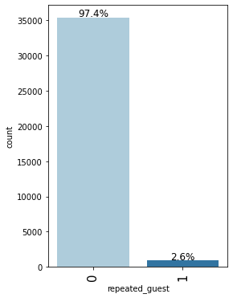

```python
labeled_barplot(data, "repeated_guest", perc=True)
```

Only 2.6% of total bookings were repeat guests.

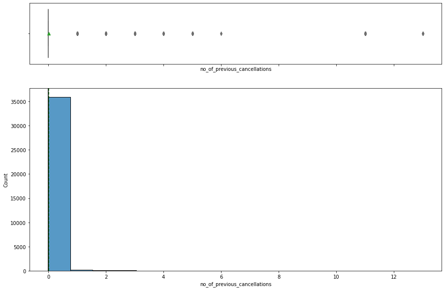

```python
histogram_boxplot(data, "no_of_previous_cancellations")
```

```python
data["no_of_previous_cancellations"].value_counts()
```

```
0     35937
1       198
2        46
3        43
11       25
5        11
4        10
13        4
6         1
Name: no_of_previous_cancellations, dtype: int64
```

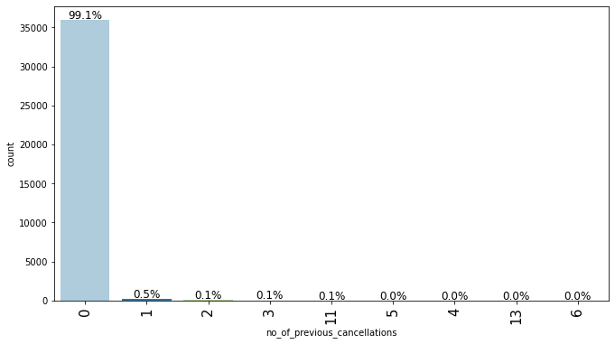

```python
labeled_barplot(data, "no_of_previous_cancellations", perc=True)
```

99.1% of all bookings did not have a previous cancellation.

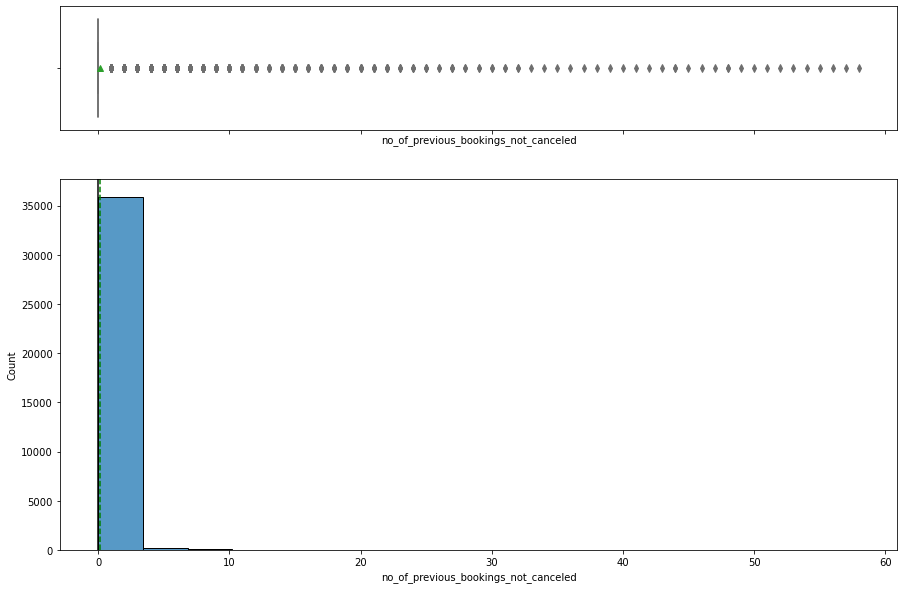

```python
histogram_boxplot(data, "no_of_previous_bookings_not_canceled")
```

[figure not shown]

```python
labeled_barplot(data, "no_of_previous_bookings_not_canceled", perc=True)
```

```python
data["avg_price_per_room"].mean()
```

```
103.4235390764958
```

The average price per room is 103.42 euros.

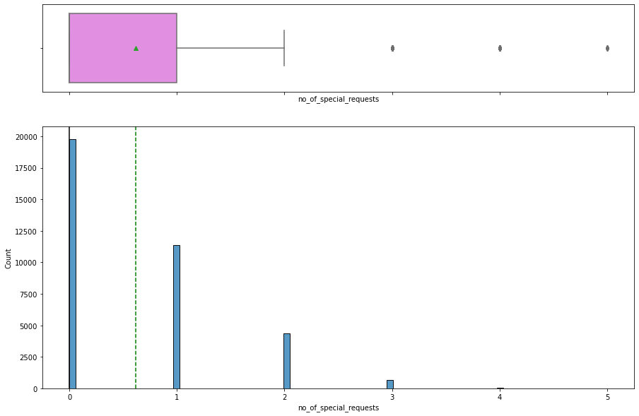

```python
histogram_boxplot(data, "no_of_special_requests")
```

```python
data["no_of_special_requests"].value_counts()
```

```
0    19777
1    11373
2     4364
3      675
4       78
5        8
Name: no_of_special_requests, dtype: int64
```

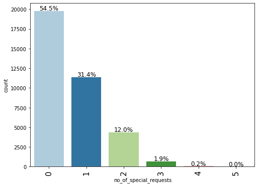

```python
labeled_barplot(data, "no_of_special_requests", perc=True)
```

54.5% of all bookings do not have a special request. 45.5% have at least one special request.

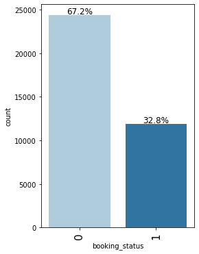

```python
labeled_barplot(data, "booking_status", perc=True)
```

```python
data["booking_status"].value_counts()
```

```
0    24390
1    11885
Name: booking_status, dtype: int64
```

32.8% of total bookings or 11885 bookings were cancelled.

##### Bivariate Analysis

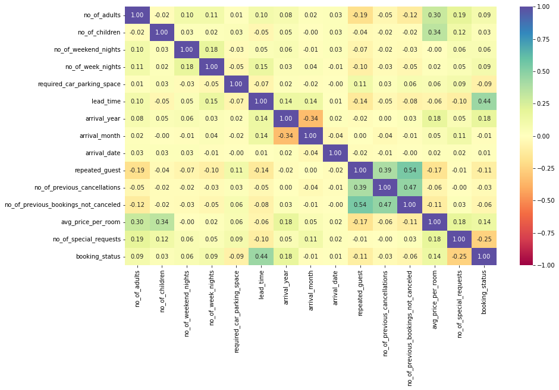

```python
plt.figure(figsize=(14, 8))
sns.heatmap(data.corr(), annot=True, vmin=-1, vmax=1, fmt=".2f", cmap="Spectral")
plt.show()
```

There is a positive correlation between #of adults and price per room, #of children and price per room, lead time and booking status, and repeat guest and booking not cancelled.

There is negative correlation between booking status and number of special requests.

###### Question 1: What are the busiest months in the Hotel?

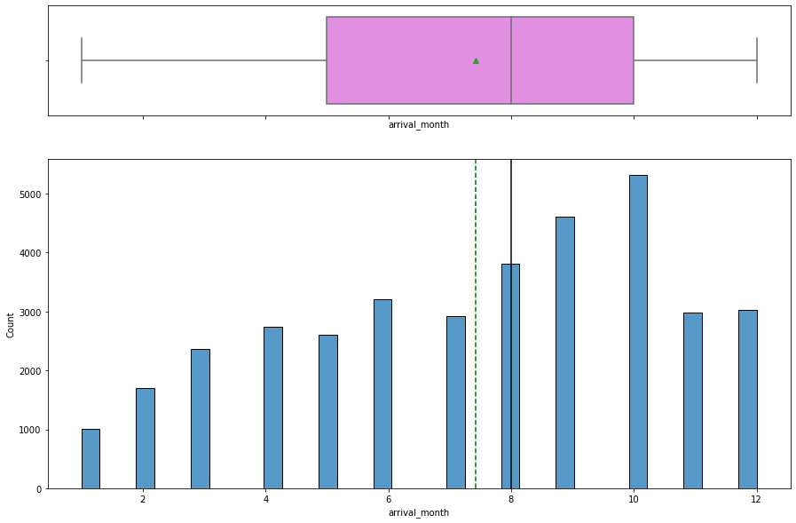

```python
histogram_boxplot(data, "arrival_month")
```

```python
data["arrival_month"].value_counts()
```

```
10    5317
9     4611
8     3813
6     3203
12    3021
11    2980
7     2920
4     2736
5     2598
3     2358
2     1704
1     1014
Name: arrival_month, dtype: int64
```

```
booking_status      0      1    All
arrival_month
All             24390  11885  36275
10               3437   1880   5317
9                3073   1538   4611
8                2325   1488   3813
7                1606   1314   2920
6                1912   1291   3203
4                1741    995   2736
5                1650    948   2598
11               2105    875   2980
3                1658    700   2358
2                1274    430   1704
12               2619    402   3021
1                 990     24   1014
------------------------------------------------------------------------------------------------------------------------
```

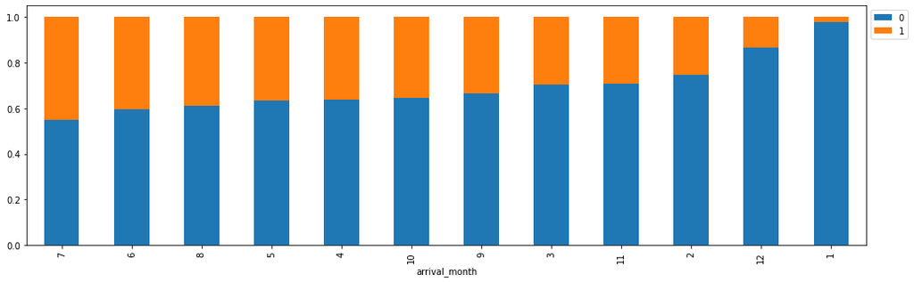

```python
stacked_barplot(data, "arrival_month", "booking_status")
```

The busiest months in the hotel based on non-cancelled reservations are October, September, December, August, and November.